# Part 3 Predictive Modeling

```python
import pandas as pd
import pandas_profiling
import numpy as np
import matplotlib.pyplot as plt
import seaborn as sns
import json
```

```python
json_file = 'ultimate_data_challenge.json'
json_data = json.load(open(json_file))
df = pd.io.json.json_normalize(json_data)
df.head()
```

|  | avg_dist | avg_rating_by_driver | avg_rating_of_driver | avg_surge | city | last_trip_date | phone | signup_date | surge_pct | trips_in_first_30_days | ultimate_black_user | weekday_pct |
| --- | --- | --- | --- | --- | --- | --- | --- | --- | --- | --- | --- | --- |
| 0 | 3.67 | 5.0 | 4.7 | 1.10 | King's Landing | 2014-06-17 | iPhone | 2014-01-25 | 15.4 | 4 | True | 46.2 |
| 1 | 8.26 | 5.0 | 5.0 | 1.00 | Astapor | 2014-05-05 | Android | 2014-01-29 | 0.0 | 0 | False | 50.0 |
| 2 | 0.77 | 5.0 | 4.3 | 1.00 | Astapor | 2014-01-07 | iPhone | 2014-01-06 | 0.0 | 3 | False | 100.0 |
| 3 | 2.36 | 4.9 | 4.6 | 1.14 | King's Landing | 2014-06-29 | iPhone | 2014-01-10 | 20.0 | 9 | True | 80.0 |
| 4 | 3.13 | 4.9 | 4.4 | 1.19 | Winterfell | 2014-03-15 | Android | 2014-01-27 | 11.8 | 14 | False | 82.4 |

```python
df.dtypes
```

```
avg_dist                  float64
avg_rating_by_driver      float64
avg_rating_of_driver      float64
avg_surge                 float64
city                       object
last_trip_date             object
phone                      object
signup_date                object
surge_pct                 float64
trips_in_first_30_days      int64
ultimate_black_user          bool
weekday_pct               float64
dtype: object
```

```python
df['last_trip_date'] = pd.to_datetime(df['last_trip_date'])
df['signup_date'] = pd.to_datetime(df['signup_date'])
```

```python
df['last_trip_date'].value_counts().sort_index().tail()
```

```
2014-06-27    1120
2014-06-28    1679
2014-06-29    2036
2014-06-30    1408
2014-07-01     548
Name: last_trip_date, dtype: int64
```

It looks like this data was pulled on July 1. I will mark everyone whose last trip date is more than 30 days before July 1 as churned.

```python
churn_date = pd.datetime(2014,7,1) - pd.Timedelta('30 days')
df['churned'] = df['last_trip_date'] < churn_date
```

```python
df.profile_report()
```

[interactive chart not shown]

#### Cleaning

- There are 8 duplicate rows that need to be removed.
- avg_rating_of_driver has too many missing values to be used
- phone has 396 missing values. I will remove these rows <1%.
- The date variables can not be used in modeling.

##### 37.6% of users were retained.

```python
df = df.drop(df[df.duplicated()].index)
df = df.drop(['avg_rating_of_driver', 'last_trip_date', 'signup_date'], axis=1)
df = df.dropna()
```

```python
df.shape
```

```
(49398, 10)
```

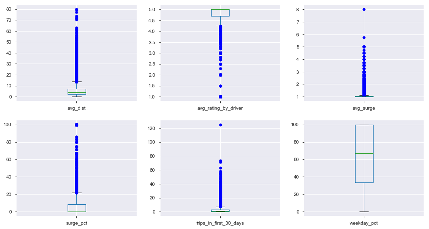

```python
continuous = df.loc[:,(df.dtypes == 'float64') | (df.dtypes == 'int64')].copy()
f, axes = plt.subplots(2, 3, figsize=(15,8))
for k, col in enumerate(continuous.columns):
    continuous.boxplot(column=col, ax=axes[k//3, k%3], sym='bo')
```

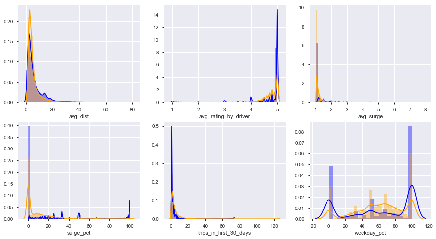

```python
f, axes = plt.subplots(2, 3, figsize=(15,8))
for k, col in enumerate(continuous.columns):
    sns.distplot(continuous.loc[df['churned'], col], ax=axes[k//3, k%3], color='b')
    sns.distplot(continuous.loc[~df['churned'], col], ax=axes[k//3, k%3], color='orange')
```

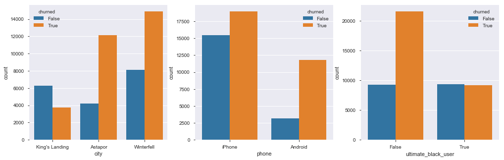

```python
f, axes = plt.subplots(1, 3, figsize=(17,5))
sns.countplot(df['city'], ax=axes[0], hue=df['churned'])
sns.countplot(df['phone'], ax=axes[1], hue=df['churned'])
sns.countplot(df['ultimate_black_user'], ax=axes[2], hue=df['churned'])
```

#### Insights

```python
def remove_outlier(df, col):
    quartiles = np.percentile(df[col].dropna(), [25, 75])
    iqr = quartiles[1] - quartiles[0]
    whisker = quartiles[1] + (iqr * 1.5)
    df.loc[df[col] > whisker, col] = whisker

remove_outlier(df, 'avg_dist')
remove_outlier(df, 'surge_pct')
remove_outlier(df, 'trips_in_first_30_days')
```

```python
from sklearn.model_selection import train_test_split
from sklearn.linear_model import LogisticRegressionCV
from sklearn.ensemble import RandomForestClassifier
from sklearn.metrics import classification_report, confusion_matrix, auc, roc_curve
```

```python
X = df.iloc[:, :-1].copy()
y = df.iloc[:, -1].copy()
X = pd.get_dummies(X, drop_first=True)
X_train, X_test, y_train, y_test = train_test_split(X, y, test_size=0.25, random_state=42)
```

```python
lr = LogisticRegressionCV()
lr.fit(X_train, y_train)
y_pred = lr.predict(X_test)
print(classification_report(y_pred, y_test))
```

```
              precision    recall  f1-score   support

       False       0.51      0.69      0.58      3493
        True       0.86      0.74      0.79      8857

   micro avg       0.72      0.72      0.72     12350
   macro avg       0.68      0.71      0.69     12350
weighted avg       0.76      0.72      0.73     12350
```

```python
print(confusion_matrix(y_pred, y_test))
```

```
[[2411 1082]
 [2347 6510]]
```

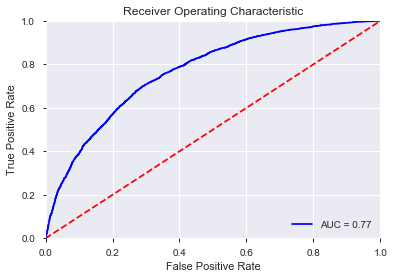

```python
probs = lr.predict_proba(X_test)
preds = probs[:,1]
fpr, tpr, threshold = roc_curve(y_test, preds)
roc_auc = auc(fpr, tpr)

# method I: plt
import matplotlib.pyplot as plt
plt.title('Receiver Operating Characteristic')
plt.plot(fpr, tpr, 'b', label = 'AUC = %0.2f' % roc_auc)
plt.legend(loc = 'lower right')
plt.plot([0, 1], [0, 1],'r--')
plt.xlim([0, 1])
plt.ylim([0, 1])
plt.ylabel('True Positive Rate')
plt.xlabel('False Positive Rate')
plt.show()
```

```python
rf = RandomForestClassifier()
rf.fit(X_train, y_train)
y_pred = rf.predict(X_test)
print(classification_report(y_pred, y_test))
```

```
              precision    recall  f1-score   support

       False       0.68      0.66      0.67      4899
        True       0.78      0.79      0.79      7451

   micro avg       0.74      0.74      0.74     12350
   macro avg       0.73      0.73      0.73     12350
weighted avg       0.74      0.74      0.74     12350
```

```python
print(confusion_matrix(y_pred, y_test))
```

```
[[3224 1675]
 [1534 5917]]
```

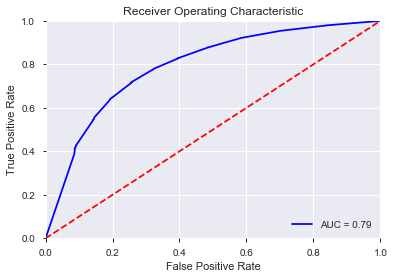

```python
probs = rf.predict_proba(X_test)
preds = probs[:,1]
fpr, tpr, threshold = roc_curve(y_test, preds)
roc_auc = auc(fpr, tpr)

# method I: plt
import matplotlib.pyplot as plt
plt.title('Receiver Operating Characteristic')
plt.plot(fpr, tpr, 'b', label = 'AUC = %0.2f' % roc_auc)
plt.legend(loc = 'lower right')
plt.plot([0, 1], [0, 1],'r--')
plt.xlim([0, 1])
plt.ylim([0, 1])
plt.ylabel('True Positive Rate')
plt.xlabel('False Positive Rate')
plt.show()
```

```python
pd.DataFrame(rf.feature_importances_, index=X.columns).sort_values(by=0, ascending=False)
```

|  | 0 |
| --- | --- |
| avg_dist | 0.334086 |
| weekday_pct | 0.161485 |
| avg_rating_by_driver | 0.140885 |
| trips_in_first_30_days | 0.077424 |
| avg_surge | 0.071084 |
| city_King's Landing | 0.064912 |
| surge_pct | 0.062833 |
| phone_iPhone | 0.039925 |
| ultimate_black_user | 0.031380 |
| city_Winterfell | 0.015986 |

```python
df.loc[df['churned'],['avg_dist', 'weekday_pct']].describe()
```

|  | avg_dist | weekday_pct |
| --- | --- | --- |
| count | 30763.000000 | 30763.000000 |
| mean | 5.504221 | 60.645057 |
| std | 4.121366 | 40.925785 |
| min | 0.000000 | 0.000000 |
| 25% | 2.320000 | 20.000000 |
| 50% | 4.030000 | 69.200000 |
| 75% | 7.790000 | 100.000000 |
| max | 13.695000 | 100.000000 |

```python
df.loc[~df['churned'],['avg_dist', 'weekday_pct']].describe()
```

|  | avg_dist | weekday_pct |
| --- | --- | --- |
| count | 18635.000000 | 18635.000000 |
| mean | 4.807527 | 61.366123 |
| std | 3.269065 | 29.455281 |
| min | 0.000000 | 0.000000 |
| 25% | 2.560000 | 44.400000 |
| 50% | 3.730000 | 64.300000 |
| 75% | 5.890000 | 84.600000 |
| max | 13.695000 | 100.000000 |

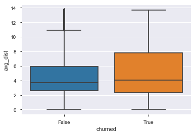

```python
sns.boxplot(x='churned', y='avg_dist', data=df)
```

The 75 percentile of those who stayed with Ultimate is lower than those who left.

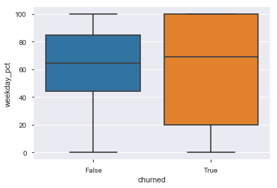

```python
sns.boxplot(x='churned', y='weekday_pct', data=df)
```

Looking at this boxplot and the distribution plotted earlier, customers who churned were more likely to either use Ultimate on only weekdays or to never use it on a weekday.